# Practical Machine Learning Week 4 Assignment

Seán Finn

26/8/2018

## Data Analysis

### Description, Objective & Assumptions

The data represents multi-senor recordings of dumbbell exercise, using sensors such as gyroscopes, accelerometers, etc., attached to various positions on the body of the test subject, and on the dumbbell itself. Data was obtained from the [Groupware@LES group](https://web.archive.org/web/20161224072740/http:/groupware.les.inf.puc-rio.br/har)

The subjects attempted to perform static dumbbell curls, using the correct form (encoded as *classe* = A), and various incorrect forms (*classe* = [B,C,D,E] ) The stated objective of this assignment is:

> … to predict the manner in which they did the exercise. This is the “classe” variable in the training set.

The following assumptions are made:

1. The objective statement above is taken to mean building a Machine Learning (ML) model which can predict the *classe* of each sample (row) of this data.
2. In building the ML model, only measurement data from the sensors should be taken into account (i.e. the user performing the exercise, and timing-related features should be discarded). This means that the data will not be treated as a sequence of time series, e.g. each data sample will be treated individually
3. Features with large amounts of missing values (> 90% in the training set) will be taken as coming from faulty sensors and are not considered.

Source for all functions referenced in this report can be found in the markdown (.Rmd) file.

### Data Exploration & Cleaning

The data was provided in two CSV files. This is loaded and some initial exploration of the data is performed:

```r
dataBuildRaw1<-read.csv('pml-training.csv',header=T,na.strings=c('#DIV/0!','NA','""') ) # model building
dataEvalRaw1<-read.csv('pml-testing.csv',header=T,na.strings=c('#DIV/0!','NA','""')) # final evaluation
```

Raw data contains 160 features: 19622 samples for model building and 20 for final evaluation.

### Non-training Columns

```r
nonTrainingFeatures <- c("X","user_name","raw_timestamp_part_1","raw_timestamp_part_1","cvtd_timestamp","new_window","num_window")
dataBuildRaw2 <- dataBuildRaw1[,!(colnames(dataBuildRaw1) %in% nonTrainingFeatures)]
dataEvalRaw2 <- dataEvalRaw1[,!(colnames(dataEvalRaw1) %in% nonTrainingFeatures)]
```

### Missing Values

A cursory glance over the data indicates some features in the data appear to have many missing values. Setting a safe limit of 90% for the maximum number of missing samples for which imputation can still work, features exceeding this are discarded. Feature vectors which have less than 90% missing values can be imputed, but none are found:

```r
maxNAfrac <- 0.9
countNAs <- function(x) { sum(is.na(x)) / length(x)}
NAfractions <- vapply(dataBuildRaw1[1:ncol(dataBuildRaw1)],countNAs,FUN.VALUE=vector(length=1,mode="numeric"))
featNamesAlmostEmpty <- colnames(dataBuildRaw1)[NAfractions > maxNAfrac]
featNamesReqImputation <- colnames(NAfractions)[(NAfractions > 0.0) & (NAfractions <= maxNAfrac)]
# remove columns which are almost empty (>90% NA)
dataBuildRaw3<-dataBuildRaw2[!colnames(dataBuildRaw2) %in% featNamesAlmostEmpty]
dataFinalEval<-dataEvalRaw2[!colnames(dataEvalRaw2) %in% featNamesAlmostEmpty] # also remove from eval data
nFeats <- ncol(dataBuildRaw3)
```

This resulted in the removal of 100 features, leaving 54 for use. There were 0 features requiring imputation (with some NA values but less than 90%).

### Outliers

Next the data was examined for extreme outliers, which could cause issue with some models. The usual definition of an outlier is a value farther than 1.5 times the Inter Quartile Range (IQR) outside the IQR, but here *extreme outliers* are defined as those farther than 10 times the IQR. These samples are first identified, and the distribution of an example feature which contains such outliers is plotted:

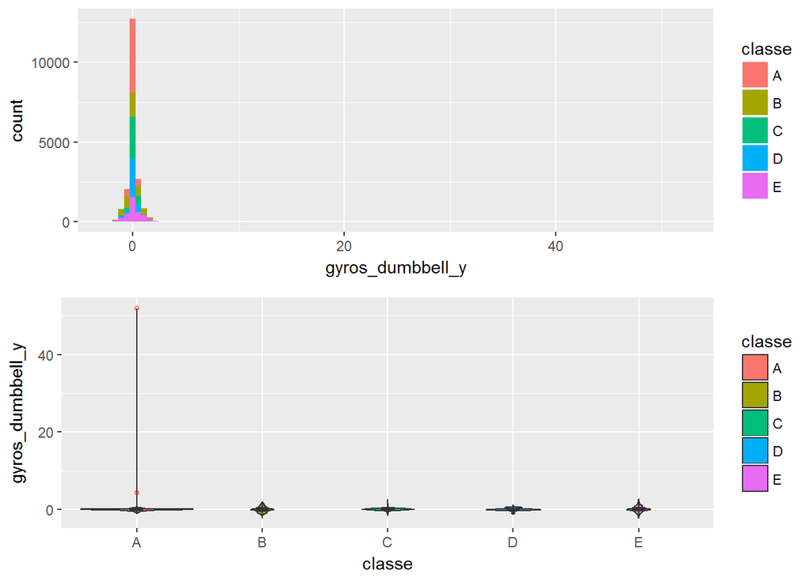

```r
numericFeats<-vapply(dataBuildRaw3, function(x){any(class(x) == c("numeric", "integer"))},FUN.VALUE=vector(l=1,m="logical"))
OLindecies <- lapply(dataBuildRaw3[,numericFeats], findOLs, outlierIQRscale=10.0)
featsWithOLs <- which(sapply(OLindecies, function(x) {length(x) > 0}))
makeFeaturePlot(dataBuildRaw3,names(featsWithOLs[3]),"classe", outlierIQRscale=10.0) # examine one of these
```

These extreme outliers are removed, and the effect of this operation on the distribution of the example feature is shown:

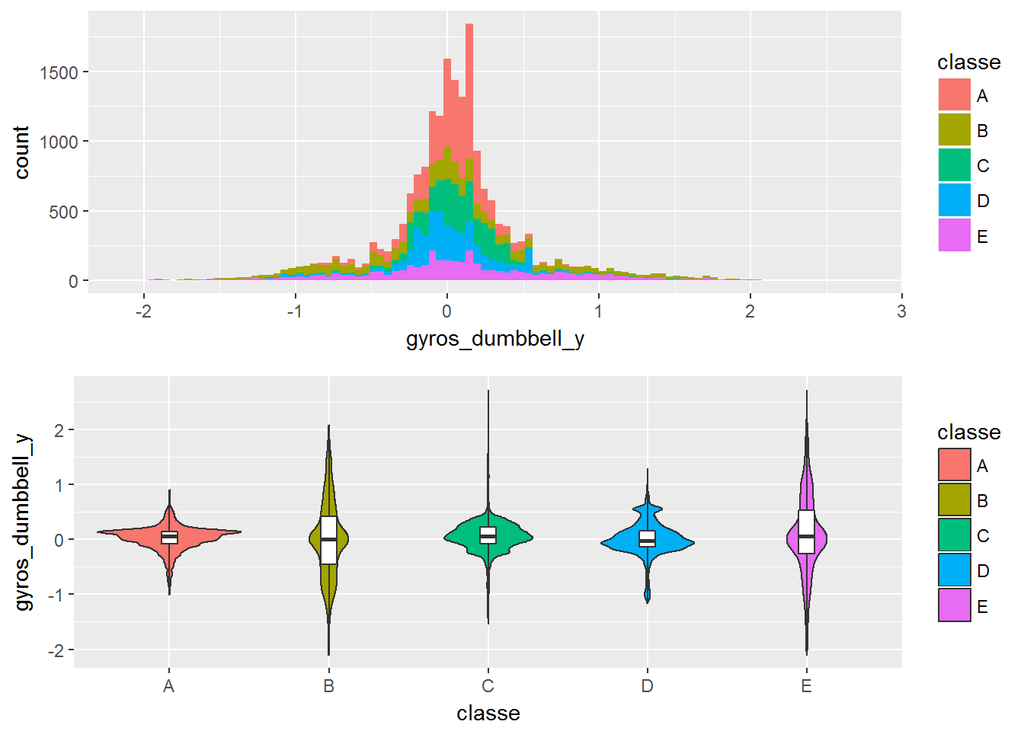

```r
OLindecies<-unique(unlist(OLindecies)) # transform into a vector of unique indecies, over all features
dataBuild<-dataBuildRaw3[-OLindecies,] # remove those outliers from the building data
makeFeaturePlot(dataBuild,names(featsWithOLs[3]),"classe", outlierIQRscale=10.0) # examine one of these
```

Post data cleaning the data contains 54 features: 19606 samples for model building and 20 for final evaluation. Examining the prevalence of each output class, it can be seen that there is a modest imbalance in favour of class A. Thus we will use the kappa score as a performance metric, instead of simple accuracy.

```r
performanceMetric <- "Kappa"
table(dataBuild$classe)/nrow(dataBuild)
```

```
##
##         A         B         C         D         E
## 0.2843517 0.1936142 0.1745384 0.1640314 0.1834642
```

## Model Development & Selection

### Data Preprocessing

The data were preprocessed such that each feature was normalised and scaled:

```r
 # transform all features expect the last (outcome, "classe") to mean 0 and range 1
preProcObj <- preProcess(dataBuild[,-ncol(dataBuild)], method=c('center','scale'))
dataBuildPreProc <- predict(preProcObj, dataBuild) # apply to building data
dataEvalPreProc <- predict(preProcObj, dataFinalEval) # apply the same to the validation data
validate <- dataEvalPreProc
```

### Data Partitioning

The ‘building’ data was split into:

1. *training*, for use in building models.
2. *testing*, for evaluating and comparing different models

The final *validation* set of 20 samples, provided in the file *pml-testing.csv* was applied only once to the finally selected model.

```r
# split the full building dataset into training and validation
trainFullIndx <- createDataPartition(y=dataBuildFull$class, p=0.7,list=FALSE)
train <- dataBuildFull[trainFullIndx,]
test <- dataBuildFull[-trainFullIndx,] #c(nrow(dataBuildFull), nrow(train), nrow(test))
```

In order to evaluate fitting performance, cross validation is used. Within each fold, both the in and out of sample errors are evaluated.

```r
nCVfolds <- 8
CVindexList_train <- createFolds(y=train$classe, k=nCVfolds, returnTrain=T, list=T)
```

A note on madel selection strategy: for each model considered, a range of parameter values are considered. For each parameter value, the both in-sample and out-of-sample errors are evaluated. A large difference between the in-sample and out-of-sample errors is a sign of overfitting.

### Model 1: Regularised Logistic Regression

Despite its name, logistic regression can be used in classification tasks. It is provided in the package [*‘LiblineaR’*](https://cran.r-project.org/web/packages/LiblineaR/) . As one of the simpler methods, it is considered here as a first approach. It has a number of parameters which can be adjusted. Here a range of values for the following parameters are fitted:

- cost: the trade-off between regularisation and correct classification on data. It is estimated in a data dependent fashion using the function *heuristicC()*.
- type: the type of linear model, which is a combination of the loss functions and the regularization scheme.

A full list of parameters and their descriptions can be found in the documentation of the *‘LiblineaR’* package.

```r
# define a grid of the all parameter values to evaluate
regLgstcParams_cost_n <- 8
regLogitParams_cost_est <- heuristicC(as.matrix(train[,-ncol(train)])) # exclude the 'classe' col
regLgstcParams_cost_vec <- lseq(from=regLogitParams_cost_est*0.01,to=regLogitParams_cost_est*100, length.out=regLgstcParams_cost_n)
regLgstcParams_type_vec <- c(0,1,4,6,7)
regLgstcParams_cost_n <- length(regLgstcParams_type_vec)
regLgstcParams_grid <- expand.grid(cost=regLgstcParams_cost_vec,type=regLgstcParams_type_vec)
```

```r
# create a data frame to store performance metrics for this classifier
perfRegLgstc <- regLgstcParams_grid # contains all parameter values
perfRegLgstc$cvInsample <- 0 # in-sample performance, estimated using cross validation
perfRegLgstc$cvOutsample <- 0 # out-of-sample performance, estimated using cross validation
perfRegLgstc$train <- 0 # in-sample performance, applied to the entire training set
perfRegLgstc$test <- 0 # in-sample performance, applied to the entire test set
modelListRegLgstc <- vector("list", nrow(regLgstcParams_grid))
for (pp in 1:nrow(regLgstcParams_grid)) { # loop over each parameter permutation
  perf_regLgstc_cvInSampleVec <- vector(l=nCVfolds,m="numeric") # store performance for each cv fold
  perf_regLgstc_cvOutSampleVec <- perf_regLgstc_cvInSampleVec
  for (ff in 1:nCVfolds) { # loop over each fold
    print(paste("> RegLgstc param ",pp,"/",nrow(regLgstcParams_grid)," cv fold ",ff,"/",nCVfolds,sep=''))
    cvFoldTrain <- train[CVindexList_train[[ff]],]
    cvFoldTest <- train[-CVindexList_train[[ff]],]
    # train model
    modRegLgstc <- LiblineaR(data=cvFoldTrain[,-ncol(cvFoldTrain)]
                               , target=cvFoldTrain$classe
                               , type =regLgstcParams_grid$type[pp]
                               , cost=regLgstcParams_grid$cost[pp]
                                )
    # apply model to predict in and out of sample error for this fold
    cvFold_trainYhat <- predict(modRegLgstc,cvFoldTrain[,-ncol(train)])$predictions
    cvFold_testYhat <- predict(modRegLgstc,cvFoldTest[,-ncol(train)])$predictions
    # measure & store performance for this fold
    perf_regLgstc_cvInSampleVec[ff] <- confusionMatrix(cvFold_trainYhat,cvFoldTrain$classe)$overall[performanceMetric]
    perf_regLgstc_cvOutSampleVec[ff] <- confusionMatrix(cvFold_testYhat,cvFoldTest$classe)$overall[performanceMetric]
  }
  # performance for this parameter set is the average of the cv folds
  perfRegLgstc$cvInsample[pp] <- mean(perf_regLgstc_cvInSampleVec)
  perfRegLgstc$cvOutsample[pp] <- mean(perf_regLgstc_cvOutSampleVec)
  # finally, train this model on the entire training set
  modelListRegLgstc[[pp]] <- LiblineaR(data=train[,-ncol(train)]
                               , target=train$classe
                               , type =regLgstcParams_grid$type[pp]
                               , cost=regLgstcParams_grid$cost[pp]
                                )
  # measure and store performance on training and test sets
  regLgstc_trainYhat <- predict(modelListRegLgstc[[pp]],train[,-ncol(train)])$predictions
  regLgstc_testYhat <- predict(modelListRegLgstc[[pp]],test[,-ncol(test)])$predictions
  perfRegLgstc$train[pp] <- confusionMatrix(regLgstc_trainYhat,train$classe)$overall[performanceMetric]
  perfRegLgstc$test[pp] <- confusionMatrix(regLgstc_testYhat,test$classe)$overall[performanceMetric]
}
# also measure the difference between training and test
perfRegLgstc$trainDifference <-  perfRegLgstc$train -  perfRegLgstc$test
```

#### Performance

To choose the best parameter value, the performance metrics are examined:

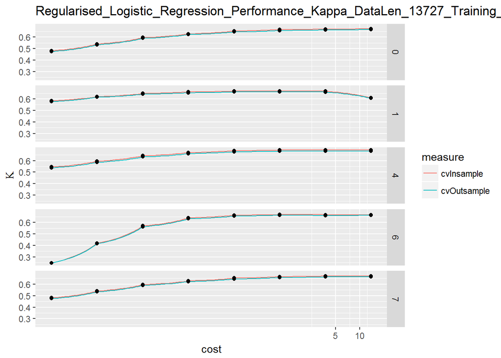

```r
plotRegLogitPerf(data=perfRegLgstc,nTr=nrow(train),performanceMetricName=performanceMetric)
```

It can be seen that this classifier did not perform particularly well, achieving a maximum kappa test set score of 0.6823553. A large difference in training and test scores can indicate overfitting. Here, the differences between training and test set scores were low (with a mean of 0.0070744 and a maximum of 0.0136127, indicating that overfitting did not occur. The method of optimal parameter selection was as follows: considering parameters which achieved testing performance within 5% of the overall maximum, and the parameter which gives the smallest training/test difference was chosen.

```r
consideredRange <- 0.05
regLogit_bestParamIndx <- which( perfRegLgstc$trainDifference ==
         min(perfRegLgstc$trainDifference[perfRegLgstc$test >= (max(perfRegLgstc$test)-consideredRange)]))
bestRegLgstc <- modelListRegLgstc[[regLogit_bestParamIndx]]
```

Using this method, the selected Regularised Logistic Regression parameter set is (*cost =* 3.7331498 , *type =* 1), which achieved a training kappa score of 0.6615979 and a test kappa score of 0.6574862.

### Model 2: Gradient Boosted Models (GBM)

Gradient Boost Models are tree-based classifiers, similar in many respects to random forests. A key difference is that GBMs are constructed through boosting, instead of the bagging approach used in random forests. Implemented in the package [*‘gbm’*](https://cran.r-project.org/web/packages/gbm/), there are a number of parameters which can be adjusted. Here a range of values for the following parameters were fitted:

- n.trees: the number of trees to fit, also occasionally referred to as the number of iterations.
- interaction.depth : maximum depth of variable interactions (1 is an additive model, 2 is a model with up to 2-way interactions, etc.).

Fixed values for other parameters were chosen as follows:

- n.minobsinnode: minimum number of observations in terminal nodes. Chosen equal to a fraction of the number of training samples in the rarest class.
- distribution: ‘multinomial’ is appropriate for multi-class classification problems such as this.
- shrinkage: the learning rate or step-size reduction. The *gbm* package documentation recommends 0.001 to 0.1, here 0.05 is used.

A full list of parameters and their descriptions can be found in the documentation of the *‘gbm’* package.

```r
# define a grid of the all parameter values to evaluate
# define a grid of the all parameter values to evaluate
gbmParams_nTreesMax <- 250 # max num trees to evaluate
gbmParams_nTrees_n <- 125
gbmParams_nTrees <- round(seq(from=20,to=gbmParams_nTreesMax,length.out=gbmParams_nTrees_n))
gbmParams_interactionIdepth_n <- 10
gbmParams_interactionIdepth <- round(seq(from=1,to=10, length.out=gbmParams_interactionIdepth_n))
#gbmParams_shrinkage_n <- 2
#gbmParams_shrinkage <- seq(from=0.05,to=0.2, length.out=gbmParams_shrinkage_n)
gbmParams_shrinkage <- 0.05
gbmParams_nMinobsinnode <- round(min(table(train$classe))*0.1)
gbmParams_grid <- expand.grid(n.trees=gbmParams_nTreesMax,interaction.depth=gbmParams_interactionIdepth,shrinkage=gbmParams_shrinkage,n.minobsinnode=gbmParams_nMinobsinnode)
gbmParams_gridPerf <- expand.grid(n.trees=gbmParams_nTrees,interaction.depth=gbmParams_interactionIdepth,shrinkage=gbmParams_shrinkage,n.minobsinnode=gbmParams_nMinobsinnode)
```

```r
# create a data frame to store performance metrics for this classifier
perfGbm <- gbmParams_gridPerf # contains all parameter values, incl all iterations
perfGbm$cvInsample <- 0 # in-sample performance, estimated using cross validation
perfGbm$cvOutsample <- 0 # out-of-sample performance, estimated using cross validation
perfGbm$train <- 0 # in-sample performance, applied to the entire training set
perfGbm$test <- 0 # in-sample performance, applied to the entire test set
modelListGbm <- vector("list", nrow(gbmParams_grid))
gbmBestIter <- vector(mode="numeric",l=nrow(gbmParams_grid))
for (pp in 1:nrow(gbmParams_grid)) { # loop over each parameter permutation
  perf_gbm_cvInSampleVec <- matrix(0.0, ncol=nCVfolds,nrow=gbmParams_nTrees_n) # store performance for each cv fold
  perf_gbm_cvOutSampleVec <- perf_gbm_cvInSampleVec
  for (ff in 1:nCVfolds) { # loop over each fold
    print(paste("> GBM param ",pp,"/",nrow(gbmParams_grid)," cv fold ",ff,"/",nCVfolds,sep=''))
    cvFoldTrain <- train[CVindexList_train[[ff]],]
    cvFoldTest <- train[-CVindexList_train[[ff]],]
    # train model
    modGbm <- gbm(  classe ~ .
                  , data = cvFoldTrain
                  , n.trees = gbmParams_grid$n.trees[pp]
                  , interaction.depth = gbmParams_grid$interaction.depth[pp]
                  , shrinkage = gbmParams_grid$shrinkage[pp]
                  , n.minobsinnode = gbmParams_grid$n.minobsinnode[pp]
                  , distribution = "multinomial"
                  , cv.folds = 0 # just one here
                  )

    # look at some of gbm's perfomance metrics: they estimare the best number of iterations / trees
    #bestInter_oob <- gbm.perf(modGbm, method= "OOB")
    for (tt in 1:length(gbmParams_nTrees)) {
      nTrees <- gbmParams_nTrees[tt]
      # apply model to predict in and out of sample error for this fold
      cvFold_trainYhat <- predict(modGbm,cvFoldTrain,nTrees)
      cvFold_testYhat <- predict(modGbm,cvFoldTest,nTrees)
      # predict.gbm() retuns class probabilities, choose largest as predicted classes
      cvFold_trainYhat <- as.factor(colnames(cvFold_trainYhat)[max.col(cvFold_trainYhat[,,1])])
      cvFold_testYhat <- as.factor(colnames(cvFold_testYhat)[max.col(cvFold_testYhat[,,1])])
      # measure & store performance for this fold
      perf_gbm_cvInSampleVec[tt,ff] <- confusionMatrix(cvFold_trainYhat,cvFoldTrain$classe)$overall[performanceMetric]
      perf_gbm_cvOutSampleVec[tt,ff] <- confusionMatrix(cvFold_testYhat,cvFoldTest$classe)$overall[performanceMetric]
    }
  }
  # performance for this parameter set is the average of the cv folds
  oerIndx1 <- (pp-1)*length(gbmParams_nTrees)+1
  oerIndx2 <- (pp)*length(gbmParams_nTrees)
  perfGbm$cvInsample[oerIndx1:oerIndx2] <- apply(perf_gbm_cvInSampleVec,1, mean)
  perfGbm$cvOutsample[oerIndx1:oerIndx2] <- apply(perf_gbm_cvOutSampleVec,1, mean)
  # finally, train this model on the entire training set
  modelListGbm[[pp]] <- gbm(  classe ~ .
                            , data = train
                            , n.trees = gbmParams_grid$n.trees[pp]
                            , interaction.depth = gbmParams_grid$interaction.depth[pp]
                            , shrinkage = gbmParams_grid$shrinkage[pp]
                            , n.minobsinnode = gbmParams_grid$n.minobsinnode[pp]
                            , distribution = "multinomial"
                            , cv.folds = 0 # just one here
  )
  # look at some of gbm's perfomance metrics: they estimare the best number of iterations / trees
  #gbmBestIter[pp] <- gbm.perf(modelListGbm[[pp]], method="OOB")
  for (tt in 1:length(gbmParams_nTrees)) {
    nTrees <- gbmParams_nTrees[tt]
    # measure and store performance on training and test sets
    gbm_trainYhat <- predict(modelListGbm[[pp]],train,n.trees=nTrees)
    gbm_testYhat <- predict(modelListGbm[[pp]],test,n.trees=nTrees)
    # predict.gbm() retuns class probabilities, choose largest as predicted classes
    gbm_trainYhat <- as.factor(colnames(gbm_trainYhat)[max.col(gbm_trainYhat[,,1])])
    gbm_testYhat <- as.factor(colnames(gbm_testYhat)[max.col(gbm_testYhat[,,1])])
    perfGbm$train[ (pp-1)*length(gbmParams_nTrees)+tt] <- confusionMatrix(gbm_trainYhat,train$classe)$overall[performanceMetric]
    perfGbm$test[ (pp-1)*length(gbmParams_nTrees)+tt] <- confusionMatrix(gbm_testYhat,test$classe)$overall[performanceMetric]
  }
}
# also measure the difference between training and test
perfGbm$trainDifference <-  perfGbm$train -  perfGbm$test
```

#### Performance

To choose the best parameter value, the performance metrics are examined:

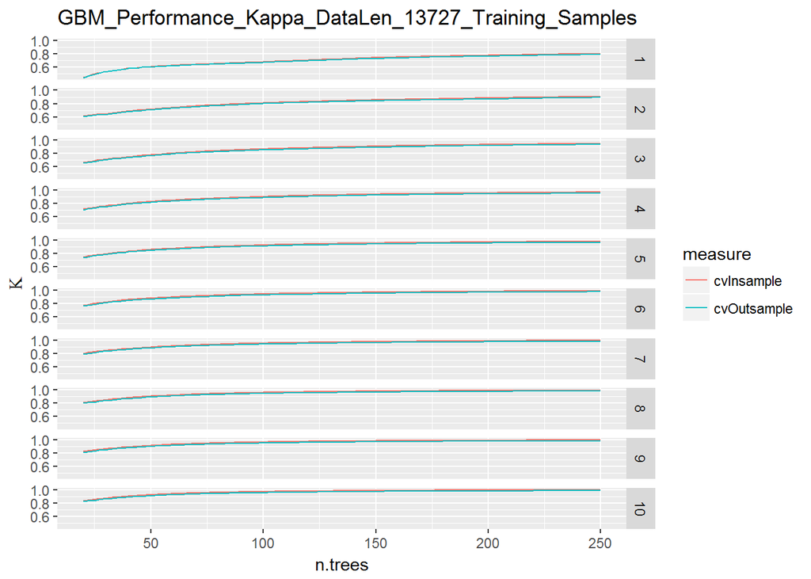

```r
plotGbmPerf(data=perfGbm,nTr=nrow(train),performanceMetricName=performanceMetric)
```

THe GBM models were capable of achieving very good performance, achieving a maximum kappa test set score of 0.9873058. The differences between training and test set scores are also low (with a mean of 0.0129285 and a maximum of 0.0184653, which indicates that overfitting did not occur. The same method of optimal parameter selection is used as for the Regularised Logistic Model was used (considering parameters which achieve testing performance within 5% of the overall maximum, the parameter which gives the smallest training/test difference was chosen).

```r
# find the parameter + interation with the best performance   # perfGbm[perfGbm$test >= (max(perfGbm$test)-consideredRange),]
gbmIter_bestParamIndx <- which( perfGbm$trainDifference ==
         min(perfGbm$trainDifference[perfGbm$test >= (max(perfGbm$test)-consideredRange)]))
# extract the best number of iterations & number
gbm_bestnIter <- perfGbm$n.trees[gbmIter_bestParamIndx]
gbm_bestParamIndx <- which(gbmParams_interactionIdepth == perfGbm$interaction.depth[gbmIter_bestParamIndx])
bestGbm <- modelListGbm[[gbm_bestParamIndx]]
bestGbmNiter <- gbm_bestnIter
bestGbmInteractionDepth <- gbmParams_interactionIdepth[gbm_bestParamIndx]

print(paste("Using this method, the selected GBM parmater set is n.trees = ", gbm_bestnIter, "interaction.depth = ", bestGbmInteractionDepth, ", which achieved a training kappa score of ", perfGbm$train[gbmIter_bestParamIndx], "and a test kappa score of ", perfGbm$test[gbmIter_bestParamIndx] ))
```

Using this method, the selected GBM parameter set is (*n.trees =* 65 , *interaction.depth =* 10), which achieved a training kappa score of 0.9489371 and a test kappa score of 0.9380325.

## Final Performance Evaluation

Taking the two models evaluated, the GBM method is selected as the best performing.

Having selected a model, the final step is to evaluate its performance on the ‘final evaluation’ dataset, provided as a separate CSV with 20 entries. This is provided without ground truth, so here the predicted classes are simply reported:

```r
final_evalYhat <- predict(bestGbm,validate,n.trees=bestGbmNiter)
validate$classe_pred <- as.factor(colnames(final_evalYhat)[max.col(final_evalYhat[,,1])]) #probs to class pred
validate[c(54,55)] # print only the last two columns
```

```
##    problem_id classe_pred
## 1           1           B
## 2           2           A
## 3           3           B
## 4           4           A
## 5           5           A
## 6           6           E
## 7           7           D
## 8           8           B
## 9           9           A
## 10         10           A
## 11         11           B
## 12         12           C
## 13         13           B
## 14         14           A
## 15         15           E
## 16         16           E
## 17         17           A
## 18         18           B
## 19         19           B
## 20         20           B
```

## Conclusions & Remarks

In this assignment the data was analysed, and extensive cleaning was performed: features with an excess of missing samples were discarded., and samples which contained extreme outliers where also discarded. A regularised logistic multiclass classifier with a range of parameters was applied, but its performance was evaluated as poor regardless of the parameter values used. A GBM model was also applied, and the optimal parameter set was found. This demonstrated an excellent rate of performance measured both as in-sample and out-of-sample errors. The small difference introduction performance between the in-sample and out-of-sample errors demonstrates that the model is able to model the information in the data without overfitting. The selected GBM model was then applied to the validation set, and the predicted values in each case were reported.